# sdbuildR: Building System Dynamics Models in R

Complex problems like climate change, geopolitical conflict, and disease have no straight-forward solutions. The field of System Dynamics aims to understand and intervene on complex systems by taking a feedback-centered view, where the interactions, nonlinearities, and delays within a system are central to addressing its problems. These systems can be mathematically described with differential equations as stock-and-flow models. Software to build and simulate stock-and-flow models is predominantly not open-access or written in domain-specific language, limiting the accessibility of this powerful technique. This paper introduces the package *sdbuildR* to build and simulate stock-and-flow models in an accessible and flexible manner in R. System Dynamics modelling in R offers five main benefits: accessibility, compatibility, flexibility, scalability, and reproducibility. In addition, *sdbuildR* can translate and has been validated with Insight Maker, an open-access online System Dynamics tool. By promoting System Dynamics modeling in R, sdbuildR aims to support a collaborative, open-source approach to further integrate and advance System Dynamics tools.

## 1 Introduction

Today’s complex problems - the climate, disease, social divide - arise within interconnected, dynamic systems. A simple, linear understanding of the problem often does not suffice, as the relation between cause and effect is rarely proportional or immediate. Complex problems require a systems approach, which considers behaviour to arise from interactions between system components over time (**kanti2017?**). Offering tools to understand and model this complexity, System Dynamics takes a feedback-centered view, where the interactions, nonlinearities, and delays within a system are central to addressing its problems. By building and simulating stock-and-flow models consisting of a set of differential equations, System Dynamics seeks to create more effective interventions. Used in fields like ecology, economics, epidemiology, and social sciences, System Dynamics has been used to design interventions for the NHS (**LaneHusemann2008?**), polioviruses (**Thompson2008?**), and the energy transition (**Gooyert2016?**), among others.

The accessibility, compatibility, flexibility, reproducibility, and scaleability offered by R could thus advance System Dynamics modelling. Likewise, the objective of System Dynamics to design better interventions could be particularly appealing to the R community, spanning fields such as social science, bioinformatics, statistics, and data science (**schilder?**). Nevertheless, System Dynamics has seen very limited engagement within the R community. Few resources for System Dynamics modelling in R exist, two notable exceptions being the book *System Dynamics Modelling with R* by Jim Duggan and the R package *readsdr* (https://github.com/jandraor/readsdr). Duggan provides an incredibly useful introduction to System Dynamics models, yet a book may be too daunting for new users to engage with System Dynamics. The package *readsdr* translates System Dynamics models from licensed software to R, and includes sensitivity and policy testing. However, the translation is limited to simple models, and the model is not easily modified without knowledge on stock-and-flow models. For more complicated models and projects requiring model flexibility, this leaves a dependency on licensed software, which aids the user to a much greater degree.

To help connect the field of System Dynamics with the R community, this paper introduces *sdbuildR*, a package to build and simulate stock-and-flow models in R. The package is designed to lower the barrier to System Dynamics modelling, emphasizing ease of use with little prior knowledge required. Model components can easily be modified, as the simulation script is compiled anew. *sdbuildR* also supports the translation of models created in Insight Maker, an open-access online tool to create, simulate, and analyse System Dynamics models. To ensure correct implementation, *sdbuildR* has been validated with over a hundred Insight Maker models. After a brief introduction into the basics of System Dynamics modelling, we illustrate how to use *sdbuildR* and its capabilities, with the aim of promoting and facilitating System Dynamics modelling in R.

## 2 Basics of System Dynamics

Introduced in the 1950s by MIT professor Jay Forrester, System Dynamics is both a conceptual tool and a modelling technique to understand the structure and dynamics of complex systems (**sterman2000?**). A central axiom of System Dynamics modelling is that the structure of a system generates its behaviour: A system’s components, interactions, nonlinearities, and delays are responsible for the events that occur over time. System Dynamics focuses on the *feedback loops* that permeate this structure. A feedback loop is “a closed chain of causal connections” (**Meadows?**) through which a variable affects itself. A simple example is how the amount of your savings determines how much they increase through interest (**Meadows?**). Feedback structures also involve information feedback, where for example drug-related crime can increase through a positive feedback loop including more police action, more arrests, less supply, higher prices, and more drug-related crime (**morecroft2015?**). Feedback thinking is directly relevant to intervention design: A major insight of System Dynamics is that hidden feedback structures commonly underlie policy resistance, unintended consequences, and counterintuitive behaviour (**sterman2000?**). By mapping out feedback structures, System Dynamics modelling is a tool to anticipate delayed and undesirable responses to interventions and design more effective policies (**sterman2000?**).

The hypothesized causal structure of a system is commonly visualised in *Causal Loop Diagrams* (CLD). As a running example throughout the rest of the paper, we will use a modified version of Crielaard et al.’s (2022) model of compensatory behaviour in eating disorders (**crielaard2022?**). In disordered eating, compensatory behaviours are to acts prevent weight gain or relieve feelings of guilt after eating, and include self-induced vomiting, laxative use and overexercise (**Stiles-Shields2012?**) Crielaard et al.’s (2022) CLD maps out the feedback loops of Food intake, Hunger, and Compensatory behaviour, with the addition of Eating triggers.[^1] A feedback loop can be balancing (i.e. counteracting, goal-seeking, negative) or reinforcing (i.e. amplifying, destabilizing, positive). In this CLD, there are four negative feedback loops: between Food intake and Hunger, between Hunger and Compensatory behaviour, between Food intake and Compensatory behaviour, and Food intake with iself. For details explaining the relation between these variables, please see Crielaard et al. (2022).

### 2.1 Stock-and-flow models

A CLD conveys the feedback structures governing the behaviour of the system. However, a CLD merely describes the structure of the system on a conceptual level. In order to simulate the behaviour of the system over time, a mathematical model is needed. A *stock-and-flow* model is one way to formally describe a system with a set of differential equations which model how the system changes over time. As a first step, the units of each variable need to be defined. Units, such as seconds, kilocalories, or people over years, quantify each variable, and help to interpret and formulate interactions between variables. *Stocks* define the state of the system. They accumulate material or information over time, such as people, products, or beliefs, which creates memory and inertia in the system (**sterman?**). Stocks are variables that can increase and decrease, and be measured at a single moment in time. The value of a Stock is increased or decreased by *Flows*. Flows move material through the system. An inflow increases a Stock, and an outflow decreases a Stock, such that the net change in a Stock is the sum of its inflows minus the sum of its outflows. Flows are defined in units of material moved over time, such as birth rates, revenue, and sales. Material may flow from and to other Stocks, or may originate from or disappear to an unspecified *source* or *sink* outside of the model. Variables included in the model are endogenous, whereas sources and sinks which are outside of the model boundary are exogenous. An exogenous source or sink is in actuality also a Stock, but is not included in the model for simplicity and parsimony (**meadows?**). As the dynamics of sinks and sources are not modeled, their capacity is infinite (**sterman?**). In addition to Stocks and Flows, a System Dynamics model may also contain two other building blocks: any other static parameters or intermediately computed variables are *Auxiliaries*, and any user-defined linear interpolation functions are *Graphical Functions* (also called converters, or table or lookup functions).

Table 1: System Dynamics Building Blocks

| Building Block | Purpose | Example |
| --- | --- | --- |
| Stock | Define the state of the system | People, products, beliefs, blood sugar, CO2 in atmosphere |
| Flow | Move material between Stocks and outside the model boundary | Birth rates, product order rates, revenue, sales |
| Auxiliary | Define static parameters or dynamic intermediate computation | Fixed prices, sum of all Stocks, ratios of flows |
| Graphical Function | Custom interpolation functions | Interventions or events occurring at known times such as vaccines or storms |

## 3 The *sdbuildR* package

To build and simulate stock-and-flow models, *sdbuildR* creates an easily modifiable object which contains all the information needed to simulate it. Users can easily add and remove variables, change equations and units Stocks, and incorporate other R functionality. As the simulation script is compiled anew each time, users are alleviated from manually updating the simulation script. The main object built by *sdbuildR* mimics the structure of the XMILE (XML Modeling Interchange LanguagE, (**Eberlein2013?**)) standard. XMILE is the main cross-platform format for System Dynamics models. Most popular System Dynamics software such as Vensim, Stella and Powersim are XMILE-compatible. XMILE uses Extensible Markup Language (XML) format, such that the model is structured using tags such as <stock> (**Bray1997?**). The main top-level tags are “sim_specs” (simulation specifications), “model” (the stock-and-flow model), “model_units” (custom-defined units), and “macro” (global variables). In the model tag, the model’s variables are separated into Stocks, Flows, Auxiliaries, and Graphical Functions.

The model is simulated using the *deSolve* package (**deSolve?**), an established package for simulating dynamical systems. Stock-and-flow models are a subset of dynamical systems, such that a dynamical system can be rewritten to an equivalent stock-and-flow model (**sterman2000?**). *deSolve* is written in C and offers a multitude of differential equation solvers, including the standard fixed timestep Runge-Kutta family, as well as a range of adaptive timestep solvers.

Below, we demonstrate how to use *sdbuildR* to build, modify, and simulate stock-and-flow models.

### 3.1 Building a Stock-and-Flow Model

```r
sdm = template("Crielaard2022")
```

```r
URL = "https://insightmaker.com/insight/5LxQr0waZGgBcPJcNTC029/Crielaard-2022"
sdm = insightmaker_to_sdm(URL)
```

```r
sdm = xmile(method = "euler",
    time_units = "hour",
    stop = 500) %>%
    build("Food.intake",
        "stock", eqn = "runif(1)",
        inflow = list(c("Feeling.hunger",
            "Eating.triggers")),
        outflow = list(c("Satiety",
            "Effect.of.compensatory.behavior")),
        label = "Food intake") %>%
    build("Hunger", "stock",
        eqn = "runif(1)",
        inflow = "Losing.energy.by.compensatory.behavior",
        outflow = "Food.intake.reduces.hunger") %>%
    build("Compensatory.behaviour",
        "stock", eqn = "runif(1)",
        inflow = "Compensating.for.having.eaten",
        outflow = "Satisfaction.with.hungry.feeling",
        label = "Compensatory behaviour") %>%
    build("Losing.energy.by.compensatory.behavior",
        "flow", eqn = "(0.3 * Compensatory.behaviour) * ((1 - Hunger) / 1)",
        label = "Losing energy by compensatory behavior") %>%
    build("Feeling.hunger",
        "flow", eqn = "((0.8 * Hunger^a0) * Food.intake) * ((1 - Food.intake) / 1)",
        label = "Feeling hunger") %>%
    build("Satiety",
        "flow", eqn = "(1.3 * (Food.intake)) * ((1 - Food.intake) / 1)") %>%
    build("Food.intake.reduces.hunger",
        "flow", eqn = "((1.4 * Food.intake^a0) * Hunger) * ((1 - Hunger) / 1)",
        label = "Food intake reduces hunger") %>%
    build("Compensating.for.having.eaten",
        "flow", eqn = "(Sig(a2 * Food.intake)) * ((1 - Compensatory.behaviour) / 1)",
        label = "Compensating for having eaten") %>%
    build("Satisfaction.with.hungry.feeling",
        "flow", eqn = "(1.3 * Hunger * Compensatory.behaviour) * ((1 - Compensatory.behaviour) / 1)",
        label = "Satisfaction with hungry feeling") %>%
    build("Eating.triggers",
        "flow", eqn = "(a1 * Food.intake) * ((1 - Food.intake) / 1)",
        label = "Effect of eating triggers") %>%
    build("Effect.of.compensatory.behavior",
        "flow", eqn = "(2 * Compensatory.behaviour * Food.intake) * ((1 - Food.intake) / 1)",
        label = "Effect of compensatory behavior") %>%
    build(c("a0", "a1",
        "a2"), "aux",
        eqn = c(1.31,
            1.5, 0.38)) %>%
    macro(name = "Sig",
        eqn = "function(x) 1 / (1 + exp(1)^(-x))")
```

For any given XMILE object, the code to build the model from scratch can be obtained with `get_build_code()`.

```r
get_build_code(template("SIR"))
```

Table 2: Properties for each Building Block

| Property | Description | Example | Stock | Flow | Auxiliary | GF |
| --- | --- | --- | --- | --- | --- | --- |
| label | Name for plotting | `'Food intake'` | x | x | x | x |
| eqn | Equation (initial value in case of Stock) | `'sqrt(10)'` | x | x | x |  |
| units | Units | `'second'` | x | x | x | x |
| non_negative | Enforce non-negativity | `FALSE` | x | x | x |  |
| min | Minimum value constraint | `0` | x | x | x | x |
| max | Maximum value constraint | `300` | x | x | x | x |
| inflow | Variable flowing into Stock | `'Hunger'` | x |  |  |  |
| outflow | Variable flowing from Stock | `'Hunger'` | x |  |  |  |
| to | Target variable of Flow | `'Hunger'` |  | x |  |  |
| from | Source variable of Flow | `'Hunger'` |  | x |  |  |
| xpts | x-domain points of GF | `c(0, 1, 2, 3)` |  |  |  | x |
| ypts | y-domain points of GF | `c(10, 12, 14, 16)` |  |  |  | x |
| interpolation | Interpolation method of GF | `'linear'` |  |  |  | x |
| rule | Rule determining behaviour of GF outside of x-domain | `2` |  |  |  | x |
| note | Add documentation to variable | `'Subjectively assessed hunger on a scale from 0 to 10'` | x | x | x | x |

Variable properties can be modified by using `build()` without the building block. In this example, the initial value of Food intake is changed:

```r
sdm = build(sdm, "Food.intake",
    eqn = 0.5)
```

To view any variable properties, use `peek()`:

```r
peek(sdm, "Food.intake",
    "eqn")
```

Variables can be removed using `erase()`:

```r
sdm = erase(sdm, name = "Food.intake")
```

Simulation specifications - the start and stop time, the time step, the time units, and the integration method - can be changed via `sim_specs()`:

```r
sdm = sim_specs(sdm,
    method = "euler",
    time_units = "day",
    start = 0, stop = 500,
    dt = 0.01)
```

An overview of the variables in the model can be obtained with `summary()`:

```r
summary(sdm)
```

```
Your model contains:
3 Stocks: Food.intake, Hunger, Compensatory.behaviour
8 Flows: Losing.energy.by.compensatory.behavior, Feeling.hunger, Satiety, Food.intake.reduces.hunger, Compensating.for.having.eaten, Satisfaction.with.hungry.feeling, Eating.triggers, Effect.of.compensatory.behavior
3 Auxiliaries: a0, a1, a2
0 Graphical Functions
```

A model diagram of the Stocks and Flows can be plotted via the *DiagrammeR* package. Stocks are indicated as vertices, Flows are indicated by arrows entering (inflows) or leaving (outflows) Stocks, and sources and sinks of Flows are indicated by open hexagons (equivalent to clouds in traditional SD diagrams).

```r
plot(sdm)
```

[interactive chart not shown]

To simulate the model, simply run `simulate()`. The timeseries of the Stocks can be plotted with `plot_stocks()`.

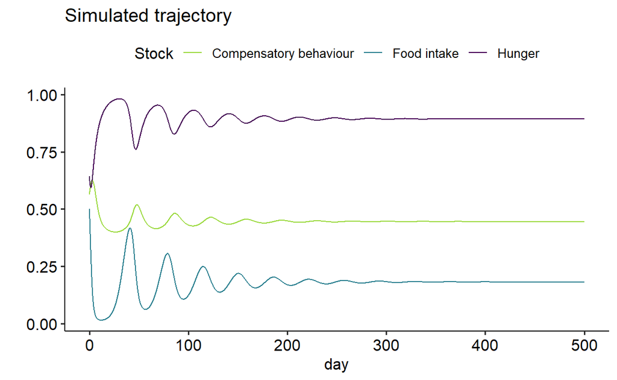

```r
sim = simulate(sdm)
plot_stocks(sdm, sim$df)
```

Table 3: Main functions in *sdbuildR*

[output not shown]

### 3.2 Model constraints

System Dynamics models can typically have three types of constraints: non-negative Flows, non-negative Stocks, and minimum and maximum value constraints. When a Flow is constrained to be non-negative, it will only ever be zero or positive by setting it to zero when negative. Similarly, non-negative Stocks always remain zero or positive by setting the update in state to zero when the net flow is negative. Finally, minimum and maximum value constraints allow the user to specify the range of values a variable may have. When this latter constraint is violated, the simulation stops.

To implement non-negativity of Stocks and Flows, *sdbuildR* constrains Flows and the change in Stocks in the ODE function. Specifically, Flows are kept non-negative using the `nonnegative()` function, which outputs 0 in case Flows are negative (preserving units in case these are specified). Stocks can be constrained to only zero or positive values by making use of the root function in *deSolve*. The root function is triggered when selected Stocks go below or exceed a certain threshold. A corresponding event function specifies the change in the state variables when the root function is triggered. To enable non-negative Stocks, the root function is triggered when selected Stocks go below zero, and are set to zero in the event function.

However, including such hard-coded constraints in the model is not recommended (**sterman2000?**). If a Stock or Flow can logically never be negative, for example in the case of animals or deaths, this should ideally arise from the model equations and parameters itself. If they unintentionally turn negative, it is likely due to model misspecification and including hard-coded constraints can lead to unexpected results (**sterman2000?**). To incorporate checks for when minimal and maximum values are crossed, each variable may have a *min* and *max* property:

```r
sdm = build(sdm, "Food.intake",
    min = 0, max = 1) %>%
    build(sdm, "Losing.energy.by.compensatory.behavior",
        max = 1)
```

```r
# Constraints of
# minimum and
# maximum value
constraints_def = list(Food.intake = c(min = 0,
    max = 1), Losing.energy.by.compensatory.behavior = c(max = 1))
constraints = get_logical_constraints(constraints_def)
print(constraints)
```

```
[1] "drop_if_units(Food.intake) < 0"
[2] "drop_if_units(Food.intake) > 1"
[3] "drop_if_units(Losing.energy.by.compensatory.behavior) > 1"
```

which outputs a vector of strings with constraints to evaluate. In the ODE, these constraints are checked using `check_constraints()`.

```r
check_constraints(constraints,
    environment(), t)
```

where `environment()` provides access to the variables computed in the ODE. When violated, the simulation stops, with a message

```
Constraint violated at time 1
drop_if_units(Food.intake) < 0: FALSE
drop_if_units(Food.intake) > 1: TRUE
drop_if_units(Losing.energy.by.compensatory.behavior) > 1: FALSE
```

```
Error in check_constraints(constraints, envir, 1):
```

### 3.3 Interpolation functions

In System Dynamics modeling, it is common to incorporate time-dependent exogenous inputs, which can represent various external influences on the system. Among these inputs are *step* functions for sudden, sustained level changes, *ramp* functions for gradual increases or decreases, *pulse* functions for instantaneous bursts, and *seasonal* functions for cyclical patterns. These functions can be created as an interpolation function using `approxfun()`, which underlies the convenience functions offered by *sdbuildR* to model these input function:

```r
times = seq(0, 50, by = 0.01)
step = make_step(times,
    start_t_step = 10,
    h_step = 20)
ramp = make_ramp(times,
    start_t_ramp = 10,
    end_t_ramp = 20)
pulse = make_pulse(times,
    start_t_pulse = 10,
    h_pulse = 10, w_pulse = 5,
    repeat_interval = 20)
seasonal = make_seasonal(times,
    peak_time = 1, "years")
```

[figure not shown]

```r
sdm = sdm %>%
    build("ramp", "aux",
        eqn = "make_ramp(times, start_t_ramp = 0, end_t_ramp = 500,
                    start_h_ramp = 1, end_h_ramp = 1)") %>%
    build("Eating.triggers",
        eqn = "(a1 * ramp(t) * Food.intake) * ((1 - Food.intake) / 1)")

sim = simulate(sdm)
plot_stocks(sdm, sim$df)
```

Similarly, a Graphical Function is also a interpolation function. With a Graphical Function, the user can create a function of any shape by giving a set of points on the x-domain and y-domain:

```r
sdm = sdm %>%
    erase("ramp") %>%
    build("ramp", "gf",
        xpts = c(0, 300,
            350, 400,
            500), ypts = c(0.1,
            0.5, 0.2,
            0.5, 1.5))


sim = simulate(sdm)
plot_stocks(sdm, sim$df)
```

[output not shown]

### 3.4 Delays, Smoothing, and Past Dependencies

Not all interactions in a system occur instantaneously. When the output of a variable lags behind its input, this is called a *delay* (Sterman, p. 411). A delay may be *fixed* (i.e. a pipeline delay) or *smooth* (i.e. first-order and higher-order delays). In the case of fixed delays, the input is delayed for a fixed delay length $\tau$ and arrives all at once. For example, material on a conveyor belt arrives at its destination after a fixed amount of time, without any mixing of materials. However, in other systems, the arrival of delayed material or information does not occur at a fixed time, but is rather a smooth process. The variability in delay time and arrival requires a smooth delay function. The simplest delay is a first-order delay function, in which an intermediate Stock (the accumulator) accrues input and releases it at a rate of $1/\tau$. This allows for intermediate mixing of material and a smooth delayed arrival of the input, as opposed to an abrupt release of all material. A first-order delay is suitable for processes with one intermediate step. When there are multiple stages in the delay process, a higher-order delay structure may be used. For example, there are multiple time delays between investment in innovation and the output of that innovation. The higher the order of the delay, the smoother the output. Higher-order delays are cascades of first-order delays, and need as many accumulators as the number of orders. Each stage is assumed to have the same time delay.

To facilitate modelling a fixed or smooth delay, *sdbuildR* sets up the necessary components of a delay structure, relieving the user from specifying this themselves. In brief, a fixed delay can be included by specifying `add_delay()` in the equation. As a first argument, the variable that is delayed is specified, followed by the length of the delay, with as an optional argument the default value when the simulation has not reached the length of the delay yet.

Note that the delay length is specified in time units, not indices, meaning a delay length of 1 with a simulation time unit “second” refers to one second in the past. Similarly, a *n*th-order delay can be included using `add_delayN()`, which takes as its first argument the variable that is delayed, as a second argument the length of the delay, as a third argument the order of the delay, and as an optional fourth argument the default value when simulation has not reached the length of the delay yet.

Table 4:

| Function Name | Purpose | Arguments |
| --- | --- | --- |
| add_delay | Add a fixed delay | Variable, delay length, (default value) |
| add_delayN | Add a smooth delay of order N | Variable, delay length, delay order, (default value) |
| add_past | Retrieve past values | Variable, (past interval) |

We briefly elaborate on how *sdbuildR* sets up the necessary components for delay structures and retrieving past values when compiling the R script or simulating the model. In the case of a fixed delay, access to a variable’s history is needed, which is not provided by deSolve in all cases. In *deSolve*, past values can only be accessed using the `lagvalue()` and `lagderiv()` function when running a delay differential equation with `dede()`. These only give access to past values of state variables and derivatives, and the Euler and Runge-Kutta 4th order solvers are not available for `dede()`. To be able to access past values of all variables using the “euler” and “rk4” integration solver, *sdbuildR* uses a different solution. In the case of fixed delays, a global dataframe *archive* is created, which keeps track of all desired variables.

```r
arhive_var = c("Food.intake")
archive <<- setup_archive(archive_var,
    times)
```

In the ODE, the archive is updated in each step using `update_archive()`, which needs the name of the global dataframe, the current timestep, and the current environment in the ODE. This convenience function allows the ODE function to remain uncluttered by individual updates for each variable, updating the archive in one sweep.

```r
update_archive("archive",
    t, environment())
```

To retrieve values from the archive, we can use either `delay()` (to retrieve a single value) or `past()` (to retrieve an interval of values). As in Insight Maker, values are linearly interpolated to deal with any numerical inaccuracies in the current time value *t* and to make the method suitable for the “rk4” solver. Notably, accessing past values is only possible when using either “euler” or “rk4” integration, not with solver methods which use variable time step sizes.

```r
past(archive, t, "Food.intake",
    pars$past_interval)
delay(archive, t, "Food.intake",
    pars$delay_length)
```

This also illustrates that any specified parameters (length and order of delay, interval of past) are added to the model as Auxiliaries.

In the case of smooth delays, a delay accumulator chain needs to be included as a Stock. The number of links in the chain is the order of the delay, such that a 10th order delay requires 10 additional Stocks. Rather than writing an individual equation for each accumulator, *sdbuildR* sets up all accumulators using `setup_delayN()`:

```r
xstart = c(xstart, setup_delayN("Food.intake_delayN_acc",
    xstart$Food.intake,
    pars$length_delayN,
    pars$order_delayN))
```

This allows the users to easily adjust the order of the delay. In the ODE, a separate variable is created to update the delay chain and to access the output of the last component in the chain.

```r
Food.intake_delayN = delayN(input,
    S[grep("^Food.intake_delayN_acc",
        names(S))], pars$length_delay,
    pars$order_delay)
```

The flow from the last accumulator in the delay chain can be accessed with the *outflow* entry (*Food.intake_delayN$outflow*). Accumulators in the delay chain are updated using the *update* entry (*Food.intake_delayN$update*), which is of the same length as the number of orders in the chain.

### 3.5 Units

Units in System Dynamics models serve two purposes: model verification and model flexibility. Units, such as meters, seconds, or degrees Fahrenheit, help the user check for logical consistency within their model. For instance, Flows need to have the units of the Stock they are connected to divided by a time unit. This means that any Flows connect to Food intake has to have the units kilocalories divided by a time unit such as hour or day. Similarly, mathematical operations between incompatible units are not allowed: *Satiety* (units Kilocalories/hour) cannot be subtracted from *Food.intake.reduces.hunger* (units Hunger intensity/hour). As such, specifying units forces users to think about the meaning of their variables and their equations.

Units also allow for greater flexibility in how each model element is defined. System Dynamics software automatically converts between units, such that variables may be defined on different levels (e.g. seconds and minutes). An error is thrown in case units are incompatible, which provides a consistent model verification check.

To implement units, *sdbuildR* uses the *units* package, which allows for flexible, comprehensive use of units. For example, to create a variable *a* of value 2 with units seconds:

```r
a = set_units(2, "second")
```

Units of a variable may be specified via:

```r
sdm = build(sdm, "Food intake",
    units = "Kilocalories")
```

All available units in the units package can be printed in a table using `units::valid_udunits()`, listing over 250 units. This table includes the definition of each unit in terms of other units. Moreover, each unit can be combined with a prefix, such as “nano”. All possible prefixes are listed in `units::valid_udunits_prefixes()`. Some units, such as “year”, may have an unexpected definition. Rather than 365 days, the unit “year” in the units package accounts for leap years, making it approximately 365.24 days. The unit “common_year” is 365 days. To check a unit’s definition, simply convert it using `set_units()` to the desired unit.

```r
set_units(set_units(1,
    "year"), "day")
```

```
365.2422 [d]
```

```r
set_units(set_units(1,
    "common_year"), "day")
```

```
365 [d]
```

```r
# set_units(set_units(1,
# 'month'), 'day')
# set_units(set_units(1,
# 'common_month'),
# 'day')
```

If these pre-defined units are insufficient, users can define their own custom units. In the XMILE format, there is a separate tag for custom units. To add these, use `model_units()` with as a first argument the symbol of the unit, as an optional second argument the definition of the unit in terms of other units, and as an optional third argument an alternative name. No definition or an empty definition creates a new base unit: a unit not defined in terms of other units. Unit symbols and names may be modified to create syntactically valid names. In this case, “Satiety Hunger Score” is changed to “Satiety_Hunger_Score”.

```r
sdm = model_units(sdm,
    name = "Satiety Hunger Score",
    eqn = "300 kilocalories",
    alias = "SHS") %>%
    build("Hunger", units = "SHS")
```

If any units are used in the R script, the *units* package is loaded at the top of the R script with:

```r
# Add package for
# specifying units
# of each model
# element
if (!require("units")) install.packages("units")
library(units)
units_options(allow_mixed = T,
    simplify = T, set_units_mode = "standard")
```

These options ensure that vectors can contain variables with different units (*allow_mixed*), that units are reduced to the most simple expression (*simplify*), and that variables can be used to set units, without being interpreted as the unit itself (*set_units_mode*, e.g. *a = ‘second’; set_units(1, a)*).

Any undefined units are installed with *sdbuildR*’s wrapper function `install_custom_units()`, which ensures any existing units of the same name are removed before installation.

Any variable without specified units is ensured to not have units using `drop_if_units()`.

On a final note, though specifying units helps with model verification, calling functions from the units package in the ODE slows down the computation considerably. Users interested in efficient simulations are recommended to ensure unit compatibility manually, without using the units package in the ODE. All unit translation can be turned off by calling `compile()` or `simulate()` with `keep_unit = FALSE`, though this is set to TRUE by default to ensure the model is reproduced accurately.

### 3.6 Macros

Global variables, i.e. macros, can be added using `macro()`:

```r
sdm = macro(sdm, name = "Sig",
    eqn = "function(x) 1 / (1 + exp(1)^(-x))")
```

Macros may be variables, functions, or any other object.

### 3.7 Implementation of `compile()`

To define variables in the correct order, the dependencies of each variable are transformed into graph “edges”, where an edge “xstart$Hunger, xstart$Food.intake” means that xstart$Hunger needs to be defined before xstart$Food.intake These edges are then fed to `topo_sort()` from the *igraph* package, which yields a correct ordering of variables (though there may be multiple ways to order them).


## 6 Conclusion

The package *sdbuildR* enables building and simulating stock-and-flow models in R, with the aim of making System Dynamics modelling accessible and flexible to fit the user’s needs. *sdbuildR* supports the use of model constraints, constructing interpolation functions, implementing ($n$th order) delays, smoothing and retrieving past values, specifying (custom) units as well as global variables. As the main object is formatted in XMILE-style, it promotes coherence with other System Dynamics software. By translating Insight Maker models, *sdbuildR* facilitates flexible and advanced use of System Dynamics modelling.

Providing the basic building blocks of stock-and-flow models is just the first step, however. System Dynamics modelling is an iterative, hands-on process, which involves defining a problem, formulating a dynamic hypothesis, formalizing a model, testing, and validation (**sterman2000?**). Fortunately, many subcomponents of this process are already supported in R. Data wrangling needed both for empirical data and simulation results is well supported by the *tidyverse* libraries (for a tutorial in the context of System Dynamics, see (**duggan2018?**)). Interactice simulations could be facilitated using a Shiny app to mimick the interface of Insight Maker (**Shiny?**). For model testing, Duggan (2017) illustrates how the R package *RUnit* can be used to validate the model (**duggan2017?**). Model validation includes structural validity - whether the system’s structure conceptually and numerically corresponds to the real world - and behavioural validity - whether simulated system behaviour matches real-world behaviour (**duggan2017?**). To identify the most influential parameters in a model, Duggan outlines how to implement statistical screening in R (**duggan2017?**).

In addition to already existing tools, the integration and development of new tools for System Dynamics becomes possible. The Python package *pysd* is an excellent demonstration of new possibilities that emerge when System Dynamics is implemented in a open-access coding language. By drawing on functionality from other packages, *pysd* enables the estimation of model parameters from empirical data using Markov-chain Monte Carlo simulation (MCMC), or even the estimation of the entire functional form of an equation using machine learning. Systems can be simulated in real-time with animated figures to better communicate the behaviour of the system over time. Support and guidance for such analyses could also be offered in R, and possible even extended. For example, AI-aided modelling can already be used to create Causal Loop Diagrams using the R package *theoraizer* (**Waaijers2024?**).

Though the efficiency and analytical abilities of licensed System Dynamics software are vast, its proprietary nature makes is naturally less accessible and less able to integrate new research and tools. For example, as of yet, artificial intelligence supported modelling is not implemented in Stella, Vensim, or Powersim, whereas *pysd* has offered this since 2017. In the same vein, *sdbuildR* is an effort to encourage the R community to engage in a collaborative effort to utilize and advance System Dynamics modelling.

Table 5: System Dynamics Building Blocks

[output not shown]

## 8 Appendix

### 8.1 Example compiled R script

```r
compile(sdm)
```

```
# Script generated on 2024-11-03 20:57:49.457178 by sdbuildR. Please cite ***

# Load packages
library(dplyr)
library(ggplot2)
library(insightmakeR1)



# Define time sequence
dt <- 0.01
times <- seq(from = 0, to = 500, by = dt)

# Simulation time unit (smallest time scale in your model)
time_units <- "day"


Sig <- function(x) 1 / (1 + exp(1)^(-x))





# Define ODE
ode_func <- function(t, S, pars) {
  S <- as.list(S)


  # Compute change in Stocks at current time t
  with(c(S, pars), {
    # Get names of variables in environment
    env_var <- names(environment())

    # Update Auxiliaries and Flows
    Losing.energy.by.compensatory.behavior <- (0.3 * Compensatory.behaviour) * ((1 - Hunger) / 1) # Flow to Hunger
    Feeling.hunger <- ((0.8 * Hunger^a0) * Food.intake) * ((1 - Food.intake) / 1) # Flow to Food.intake
    Satiety <- (1.3 * (Food.intake)) * ((1 - Food.intake) / 1) # Flow from Food.intake
    Food.intake.reduces.hunger <- ((1.4 * Food.intake^a0) * Hunger) * ((1 - Hunger) / 1) # Flow from Hunger
    Compensating.for.having.eaten <- (Sig(a2 * Food.intake)) * ((1 - Compensatory.behaviour) / 1) # Flow to Compensatory.behaviour
    Satisfaction.with.hungry.feeling <- (1.3 * Hunger * Compensatory.behaviour) * ((1 - Compensatory.behaviour) / 1) # Flow from Compensatory.behaviour
```

[output cut: 31 more lines]

```
# Turn initial condition into alphabetically ordered named vector
xstart <- unlist(xstart)[order(names(xstart))]

# Run ODE
out <- deSolve::ode(
  func = ode_func,
  y = xstart,
  times = times,
  parms = pars,
  method = "euler"
)
df <- as.data.frame(out)

# Plot ODE
plot_stocks(sdm, df)
```

In general, *deSolve*’s `ode()` only outputs state variables (i.e. Stocks). In order to generate a complete dataframe with all computed variables in the ODE, all created variables are included using `collect_var()`.

J. Cheng and C. Sievert. *crosstalk: Inter-widget interactivity for HTML widgets.* 2021. URL https://CRAN.R-project.org/package=crosstalk. R package version 1.1.1.

C. Sievert. *Interactive Web-Based Data Visualization with r, plotly, and shiny.* Chapman; Hall/CRC, 2020. URL https://plotly-r.com.

[^1]: Note that Crielaard et al.’s (2022) model was slightly modified to correspond with Sterman’s recommendations for System Dynamics models. For example, the Stock “Eating” was changed to “Food intake”, as it is recommended to use nouns or noun phrases for Stocks.